# Tema 4. Bases de datos secundarias

Actualizado en: 24/01/2023

## Objetivos

- UniProt
- Pfam
- Rfam
- ENSEMBL
- KEGG

## [UniProt](https://www.uniprot.org/)

“The Universal Protein Resource (UniProt) is a comprehensive resource for protein sequence and annotation data. The UniProt databases are the UniProt Knowledgebase (UniProtKB), the UniProt Reference Clusters (UniRef), and the UniProt Archive (UniParc). The UniProt consortium and host institutions EMBL-EBI, SIB and PIR are committed to the long-term preservation of the UniProt databases.”

## UniProt

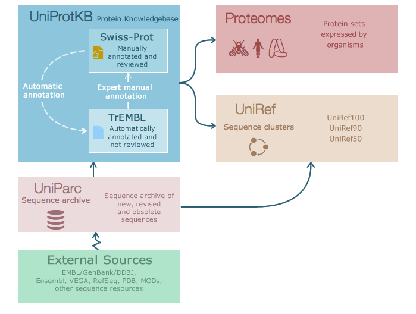

## UniProt. Cuestionario.

- ¿En qué sección de UniProt buscarías información sobre la función de una proteína?
- ¿Qué sección és menos *redundante*?
- ¿Por qué coexisten TrEMBL y Swiss-Prot?
- ¿De dónde salen los datos primarios?

## Pfam

“Pfam version 35.0 was produced at the European Bioinformatics Institute using a sequence database called Pfamseq, which is based on UniProt release 2021_03.

Pfam is freely available under the Creative Commons Zero (“CC0”) licence.

Pfam is powered by the HMMER3 package written by Sean Eddy and his group at HHMI/ Harvard University, and built by the Xfam consortium.”

## Pfam. HMMER3

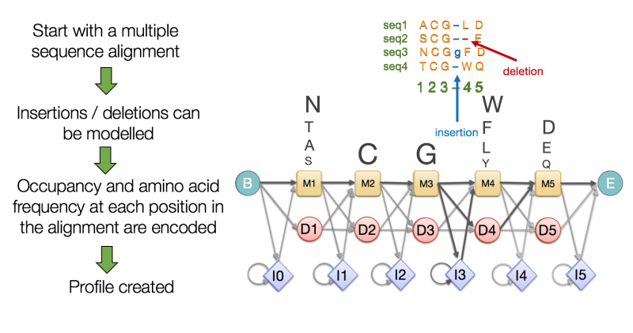

## Pfam. Para qué sirve

- Buscar proteína o DNA contra los models (perfiles HMM).
- Explorar familias de proteínas y *clanes*.
- Obtener anotación funcional de familias o dominios.
- Ver alineamientos múltiples de una familia o clan.
- Ver las relaciones entre las familias de un clan.
- Ver información de estructura tridimiensional de una familia.
- Ver familias de acuerdo a su distribución taxonómica.
- Buscar la base de datos por palabras clave.

## Pfam. Categorías de los registros

- Dominio.
- Familia.
- Repetición (*repeat*).
- Motivo.
- *Coiled-coil*
- Desordenada.

## Pfam. Clanes

Registros en Pfam relacionados por semejanza de: - secuencia, - estructura, - función, - o perfil.

## [Pfam](http://pfam.xfam.org/)

[figure not shown]

## Pfam. Resultados

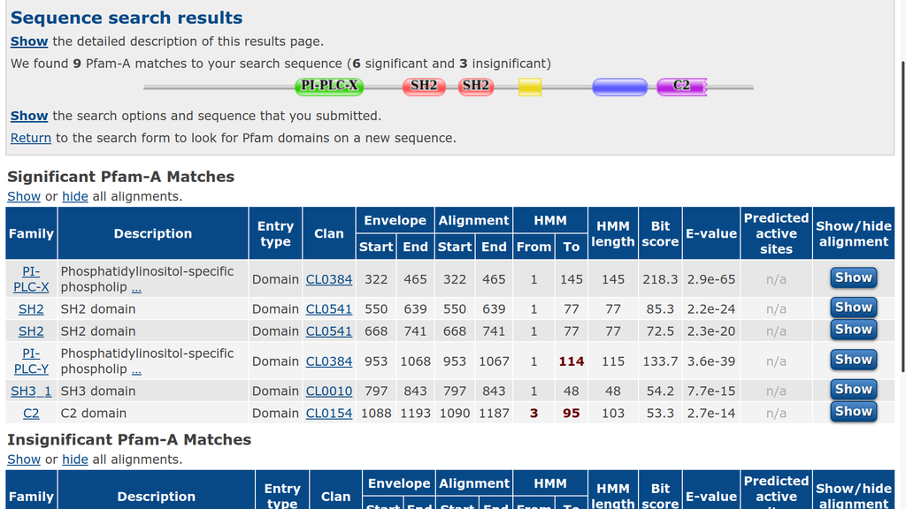

## Pfam. Acceso a los datos

- Descarga de alineaminetos, etc.
- Descarga de tablas que componen la base de datos entera (ftp).
- Acceso programatico con API **RESTful**.

## Rfam

[figure not shown]

## [ENSEMBL](https://www.ensembl.org)

**Secuencias genómicas**

\(\downarrow\)

**Predicción automática de genes**

\(\downarrow\)

**Base de datos MySQL**

\(\downarrow\)

**Análisis y visualización**

## ENSEMBL

- Servicio del EMBL-EBI.
- Originalmente para genoma humano.
- Incluye genomas de 311 especies.
- La base de datos y sus herramientas estan disponibles.

## ENSEMBL. Acceso a los datos

- Consulta y visualización.
- Opciones de descarga de resultados de búsqueda.
- Descarga de tablas por ftp.
- Perl API.
- REST API (independiente de lenguaje).

## [ENSEMBL](https://www.ensembl.org)

[figure not shown]

## KEGG

“KEGG is a database resource for understanding high-level functions and utilities of the biological system, such as the cell, the organism and the ecosystem, from molecular-level information, especially large-scale molecular datasets generated by genome sequencing and other high-throughput experimental technologies.”

## [KEGG](https://www.kegg.jp/)

[figure not shown]